# InveRness RUG - Intro to ggplot2

16 May 2016

## Aims:

Practical rather than theoretical

- ggplot today
- grammar of graphics - the very basics
- exploratory plots- scatter, bar, histogram, line
- more advanced
- some work based examples
- ggplot, the hadleyverse and everything else gg related

## ggplot2:

http://docs.ggplot2.org/current/

- Not part of standard R packages - needs to be installed
- based on ["The Grammar of Graphics"](https://www.amazon.co.uk/Grammar-Graphics-Statistics-Computing/dp/0387245448)
- Package Authors : Hadley Wickham, Winston Chang
- Version 2 released late 2015
- Last major release - but users now actively building [extensions](https://www.ggplot2-exts.org/)
- In some cases [not everyone loves it](http://simplystatistics.org/2016/02/11/why-i-dont-use-ggplot2/)
- but [most do!](http://varianceexplained.org/r/why-I-use-ggplot2/)

## The basics:

- data must be a [data frame](http://www.r-tutor.com/r-introduction/data-frame)
- all plots have same underlying structure
- build plots in layers
- can plot data from more than one data frame in same plot
- advanced plots build on basics

## ggplot2 - plot components

ggplot(data,aes(x=x,y=y))+geom_XXX()

- data: what we want to visualise
- aesthetics: x & y variables, but also applies to:
- colour, size, shape .
- geoms: the objects we draw e.g. bars,lines, points etc
- geoms inherit colour etc from the aesthetics - unless over-written
- data values are mapped to the aesthetics

## Sounds complicated - why use ggplot2?

The best answer is to try it and see:  
- default plots look good straight out of the box  
- it tries to pick suitable scales, automatic legends etc where appropriate  
- a common underlying approach for each chart type  
- base R and lattice are also complicated - you need to pick one, pick the best  
- flexibility and scope  
- carryover to over datavis software e.g. Tableau

## Packages and datasets required:

library(ggplot2)  
#library(ggExtra) # extra functionality and useful code snippets  
library(ggthemes) # change appearance  
#library(dplyr) # data wrangling  
library(tidyr) # data wrangling  
#library(lubridate) # for easy date manipulation

[code for today](https://github.com/johnmackintosh/ggplotdemo)

## Scatter plot

## Generate test data

```r
set.seed(11)
df.test <- data.frame(x = rnorm(50, mean=5, sd=2),
                           y = rnorm(50, mean=5, sd=1))
```

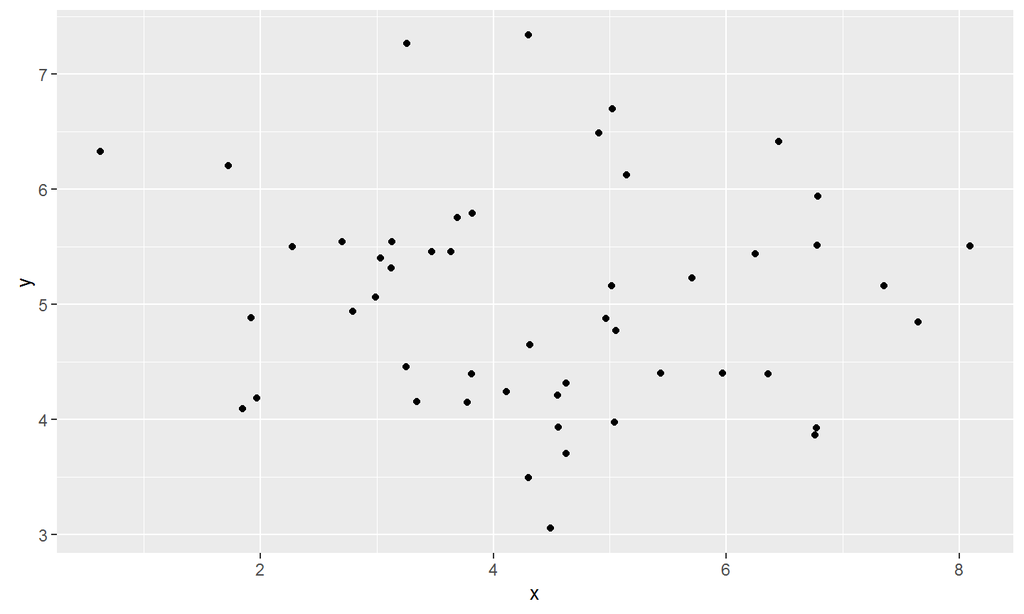

```r
ggplot(data=df.test, aes(x, y)) +
  geom_point()
```

## Change colour & size of points

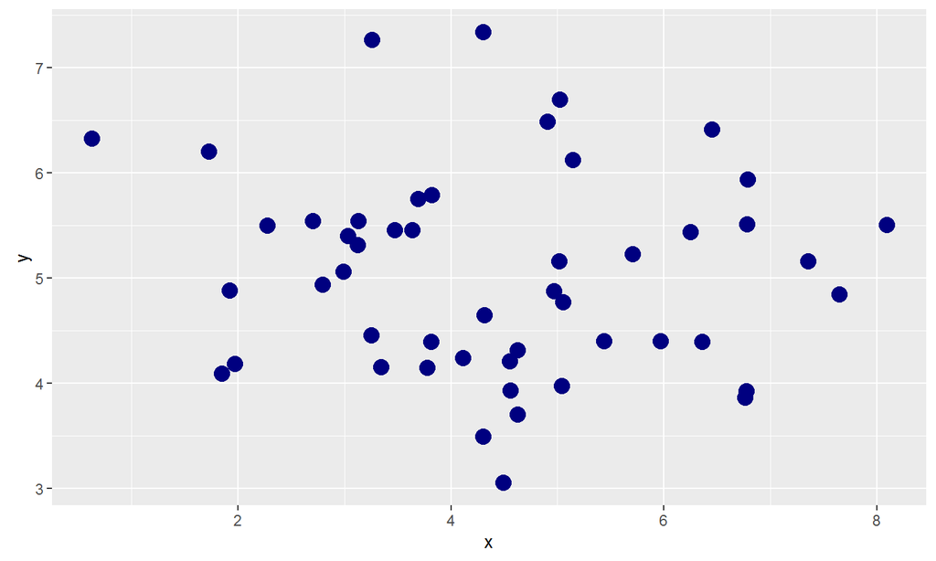

```r
ggplot(data=df.test, aes(x=x, y=y)) +
  geom_point(color="navy", size=4)
```

## Create a generic scatter plot function

```r
scatter <- function(data, x, y,...) {
  ggplot(data=data,aes(x=x,y=y))+geom_point(...)
}

#create new dummy dataframe
data2 <- data.frame(x = rnorm(100, mean=20, sd=2),
                   y = rnorm(100, mean=40, sd=1))
```

## Use function:

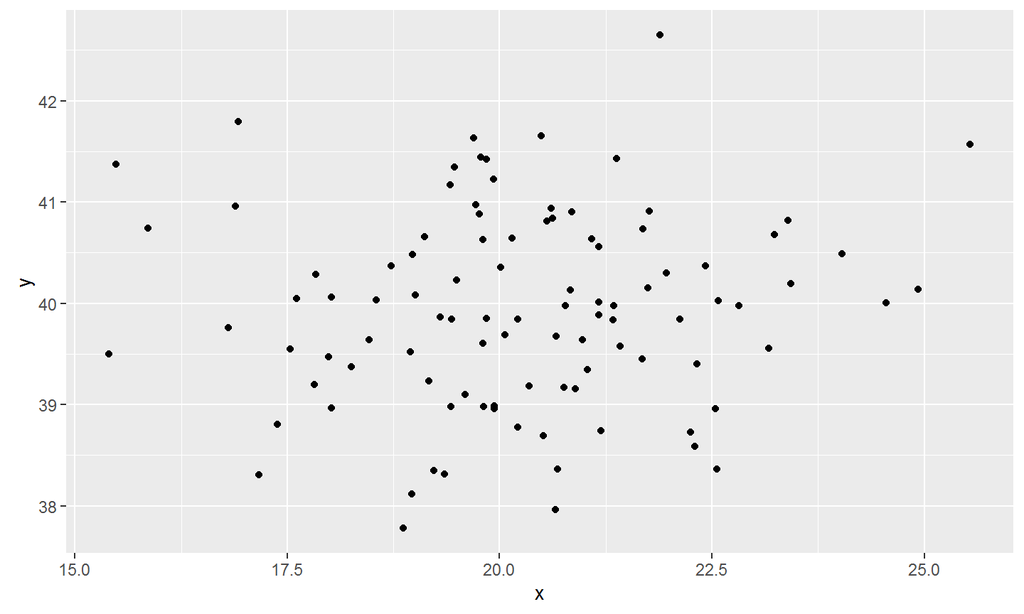

```r
scatter(data2,aes(x,y))
```

## Bar Chart

```r
# Create dummy dataset
df.dummy_data <- data.frame(cat_var = c("A","B","C","D","E"),
                            num_var = c(5,2,9,4,5)
)
```

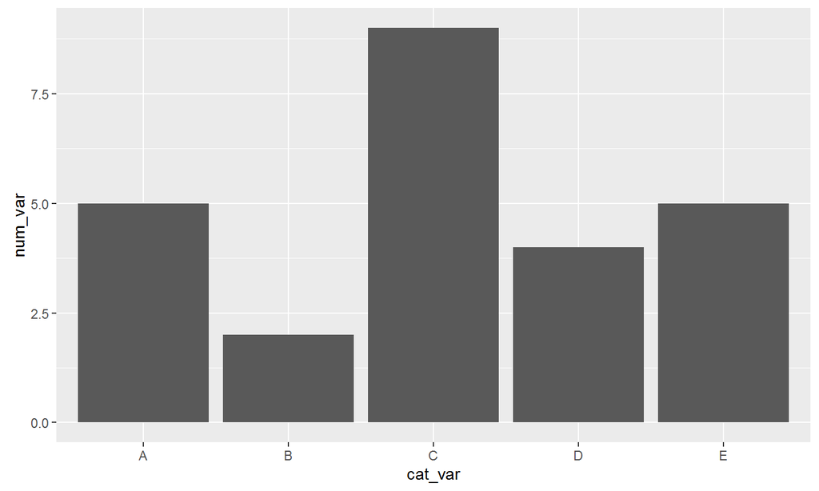

```r
ggplot(data=df.dummy_data, aes(x=cat_var, y=num_var)) +
  geom_bar(stat="identity") #map bar to values in data
```

## Default behaviour is to count

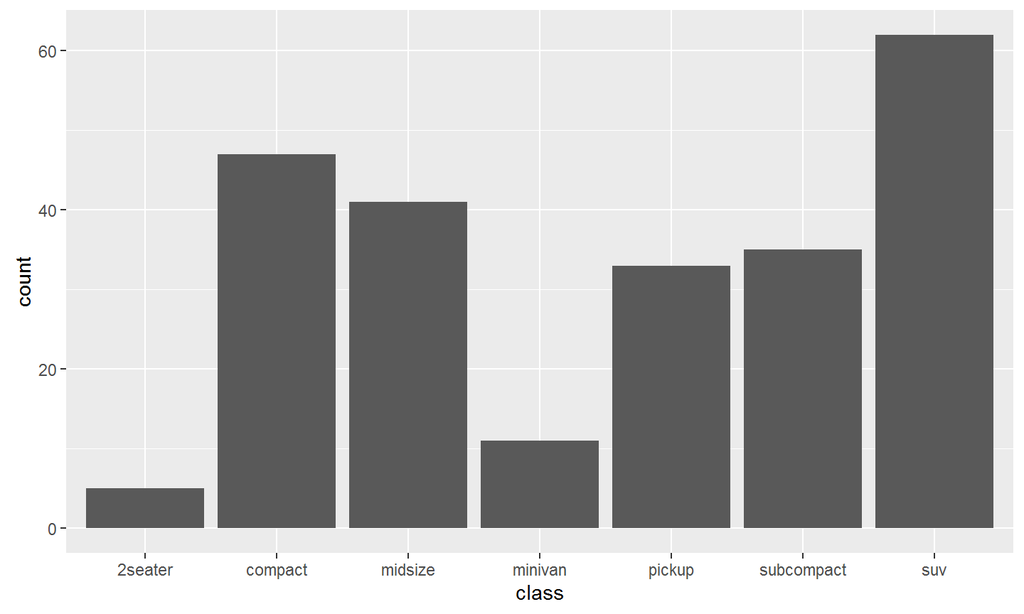

```r
g <- ggplot(mpg, aes(class))
# Number of cars in each class:
g + geom_bar()
```

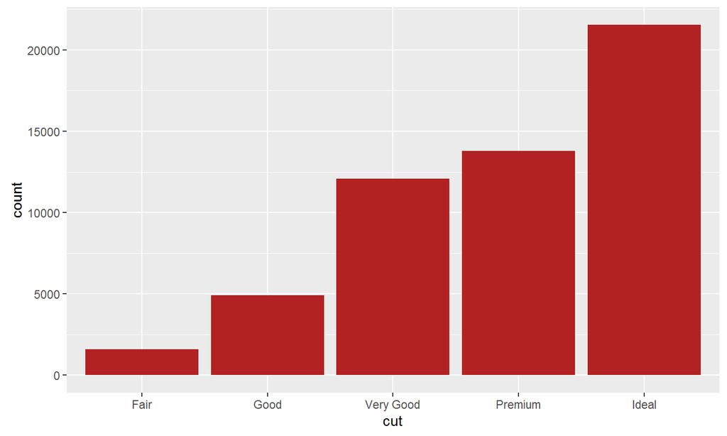

```r
p<-ggplot(data=diamonds, aes(x=cut)) +
  geom_bar(fill="firebrick") # fill in the bars
p
```

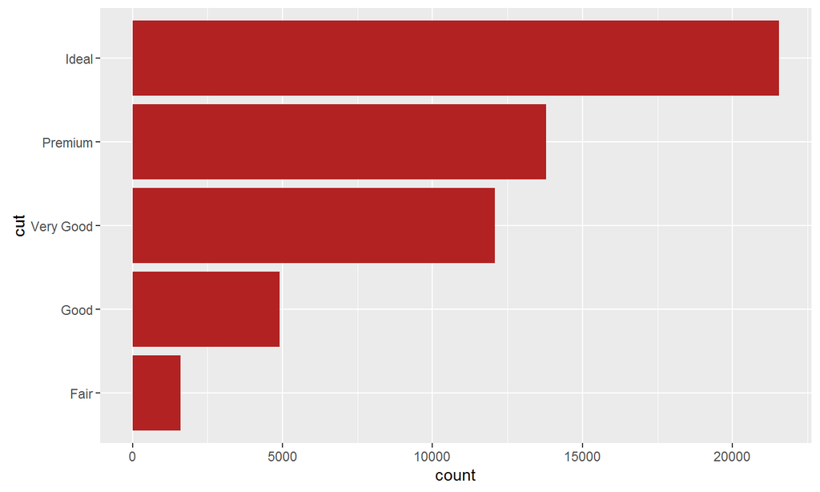

```r
p<-p + coord_flip() # flip the axis
p
```

## Histogram

## dummy data

```r
set.seed(11)
df.hist_data <- data.frame( x_var = rnorm(2000) )
```

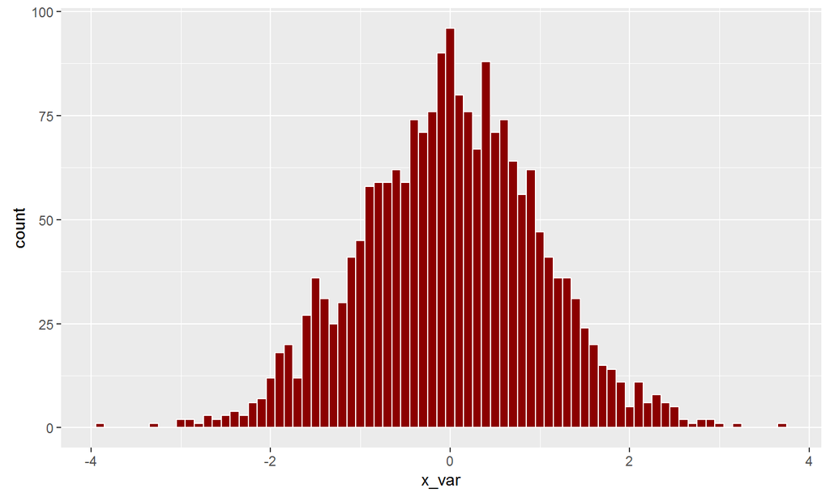

```r
ggplot(data=df.hist_data, aes(x=x_var)) +
  geom_histogram(binwidth=0.1,fill="dark red",colour="white")
```

## Line Charts

## Get the data:

```r
data<-list(fdeaths,mdeaths,ldeaths) #time series data- needs prep
data<-as.data.frame(data)
names(data)[1:3]<- c("fdeaths","mdeaths","ldeaths")
data$fdeaths<-as.numeric(data$fdeaths)
data$mdeaths<-as.numeric(data$mdeaths)
data$ldeaths<-as.numeric(data$ldeaths)
startdate<-as.Date('1974-1-1')
date<-seq.Date(startdate,by='month',length.out = 72)
data$date<-date
```

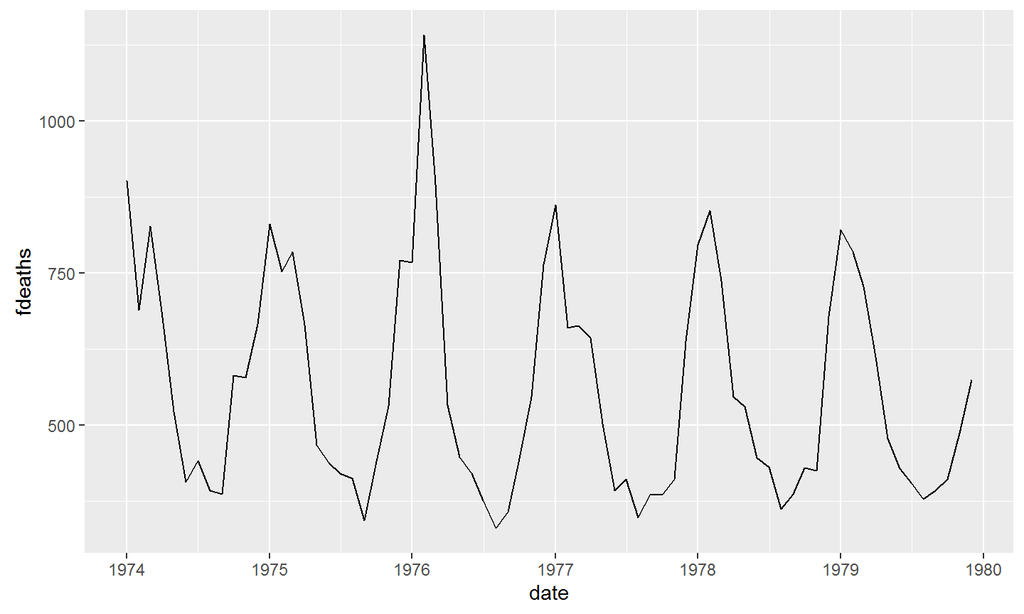

```r
ggplot(data,aes(date,fdeaths))+geom_line()
```